# Stats 506, F20, Problem Set 5

Zhihao Xu, xuzhihao@umich.edu

December 02, 2020

## About

This is the write-up solution to Problem Set 5 for Stats 506 in Fall 2020.

### Code Organization

- `ps2_q1.R` consists of the R-code for Question 1
- `ps2_q2.R` consists of the R-code for Question 2
- `ps5_writeup.R` builds the page your are reading.

## Question 1

### Research Question:

> For which Census Division has most air conditioning equipment in 2009 and 2015 and which change most from 2009 to 2015? Is this difference larger in urban or rural areas?

Click right to see the R code for answering this question.

```r
## Stats 506, Fall 2020 Problem Set 5 Question 1
##
## Author: Zhihao Xu, xuzhihao@umich.edu
## Updated: December 1, 2020
# 79: -------------------------------------------------------------------------
# libraries: ------------------------------------------------------------------
library(tidyverse)
library(data.table)

# directories: ----------------------------------------------------------------
path = './data/'

# data: -----------------------------------------------------------------------
## 2009 RECS data
recs_09 = fread(paste0(path,'recs2009_public.csv')) %>%
  .[,.(id = DOEID, division = DIVISION, w = NWEIGHT,
       ur = UR, air = AIRCOND)]
brr_names_09 = paste0('brr_weight_',1:244)
brr_09 = fread(paste0(path,'recs2009_public_repweights.csv')) %>%
  .[,-c("NWEIGHT"), with = FALSE] %>%
  .[,.(id=DOEID), brr_names_09]
## 2015 RECS data
recs_15 = fread(paste0(path,'recs2015_public_v4.csv')) %>%
  .[,.(id = DOEID, division = DIVISION, w = NWEIGHT,
       ur = UATYP10, air = AIRCOND)]
recs_15[, ur:=ifelse(ur=='R','R','U')]
brr_names_15 = paste0('BRRWT',1:96)
brr_15 = fread(paste0(path,'recs2015_public_v4.csv')) %>%
  .[,.(id=DOEID), brr_names_15]


## proportion of homes with air conditioning equipment in each group for recs 09
mean_air_ur_09 =
  recs_09[ , .(mean_air = sum(air * w) / sum(w)), keyby = .(division, ur)]

brr_long_09 = melt(brr_09, id.vars = 'id',
                   measure.vars = brr_names_09,
                   value.name = 'w', variable.name = 'repl')

mean_air_ur_repl_09 =
  merge(brr_long_09,
        recs_09[,.(id, air, division, ur)],
        by = 'id') %>%
  .[ , .(mean_air_repl = sum(air * w) / sum(w)),
     keyby = .(division, repl, ur)]

mean_air_ur_09 =
  merge( mean_air_ur_09,
         mean_air_ur_repl_09[, !"repl"],
         by = c('division', 'ur')
  ) %>%
  .[ , .( mean_air = mean_air[1],
          se = 2 * sqrt(mean({mean_air_repl - mean_air}^2))
  ), .(division, ur) ]

m = qnorm(.975)
mean_air_ur_09[ , `:=`(lwr = pmax(0, mean_air - m * se),
                       upr = pmin(1, mean_air + m * se))]

## proportion of homes with air conditioning equipment in each group for recs 15
mean_air_ur_15 =
  recs_15[ , .(mean_air = sum(air * w) / sum(w)), keyby = .(division, ur)]

brr_long_15 = melt(brr_15, id.vars = 'id', measure.vars = brr_names_15,
                    value.name = 'w', variable.name = 'repl')

mean_air_ur_repl_15 =
  merge(brr_long_15,
        recs_15[,.(id, air, division, ur)],
        by = 'id') %>%
  .[ , .(mean_air_repl = sum(air * w) / sum(w)),
     keyby = .(division, repl, ur)]

mean_air_ur_15 =
  merge( mean_air_ur_15,
         mean_air_ur_repl_15[, !"repl"],
         by = c('division', 'ur')
  ) %>%
  .[ , .( mean_air = mean_air[1],
          se = 2 * sqrt(mean({mean_air_repl - mean_air}^2))
  ), .(division, ur) ]

m = qnorm(.975)
mean_air_ur_15[ , `:=`(lwr = pmax(0, mean_air - m * se),
                    upr = pmin(1, mean_air + m * se))]


mean_air_ur_dif =
  merge(mean_air_ur_15,
        mean_air_ur_09,
        by=c('division','ur')
  ) %>%
  .[, .(dif = mean_air.x - mean_air.y,
        se = sqrt(se.x^2 + se.y^2)
  ), .(division, ur) ]
mean_air_ur_dif[ , `:=`(lwr = pmax(-1, dif - m * se),
                        upr = pmin(1, dif + m * se),
                        se=NULL)]

## order
divisions = c(
  "New England",
  "Middle Atlantic",
  "East North Central",
  "West North Central",
  "South Atlantic",
  "East South Central",
  "West South Central",
  "Mountain North",
  "Mountain South",
  "Pacific")
urs = c('Rural', 'Urban')

mean_air_ur_dif[ , `:=`(division = factor(division, rep(1:10,each=2),
                                          labels = divisions[rep(1:10,each=2)]),
                        ur = factor(ur,
                                    levels = rep(c('R','U'),10),
                                    labels=urs[rep(1:2,10)]))]
mean_air_ur_09[ , `:=`(division = factor(division, rep(1:10,each=2),
                                         labels = divisions[rep(1:10,each=2)]),
                       ur = factor(ur,
                                   levels = rep(c('R','U'),10),
                                   labels=urs[rep(1:2,10)]))]
mean_air_ur_15[ , `:=`(division = factor(division, rep(1:10,each=2),
                                         labels = divisions[rep(1:10,each=2)]),
                       ur = factor(ur,
                                   levels = rep(c('R','U'),10),
                                   labels=urs[rep(1:2,10)]))]
setkey(mean_air_ur_dif, division)
setkey(mean_air_ur_09, division)
setkey(mean_air_ur_15, division)

tab09 =
  mean_air_ur_09[ , .(division, ur,
                       ci = sprintf('<center>%4.1f <br>(%4.1f, %4.1f)</center>',
                                    100 * mean_air, 100 * lwr, 100 * upr) )
  ] %>%
  dcast(., division ~ ur, value.var = 'ci' )

setnames(tab09, c('Census Division',
                  'Rural, % <br> (95% CI)',
                  'Urban, % <br> (95% CI)'))

tab15 =
  mean_air_ur_15[ , .(division, ur,
                       ci = sprintf('<center>%4.1f <br>(%4.1f, %4.1f)</center>',
                                    100 * mean_air, 100 * lwr, 100 * upr) )
  ] %>%
  dcast(., division ~ ur, value.var = 'ci' )

setnames(tab15, c('Census Division',
                   'Rural, % <br> (95% CI)',
                   'Urban, % <br> (95% CI)'))

tabdif =
  mean_air_ur_dif[ , .(division, ur,
                        ci = sprintf('<center>%4.1f <br>(%4.1f, %4.1f)</center>',
                                     100 * dif, 100 * lwr, 100 * upr) )
  ] %>%
  dcast(., division ~ ur, value.var = 'ci' )

setnames(tabdif, c('Census Division',
                 'Rural, % <br> (95% CI)',
                 'Urban, % <br> (95% CI)'))

# DT::datatable(tab15, escape = FALSE)

p1 =
  mean_air_ur_09 %>%
  rename( rurality = ur ) %>%
  ggplot( aes( x = division, color = rurality) ) +
  geom_point( aes(y = mean_air), position = position_dodge(width = 0.5) ) +
  geom_errorbar( aes(ymin = lwr, ymax = upr),
                 position = position_dodge(width = 0.5) ) +
  theme_bw() +
  scale_color_manual( values = c("darkred", "darkblue")) +
  ylab("Proportion of Homes with Air Conditioning Equipment.") +
  xlab("Census Division") +
  coord_flip()
cap1 = paste(
  '**Figure 1.** *Estimated Proportion of Homes with Air Conditioning ',
  'Equipment by rurality in each Census Division in 2009.*')

p2 =
  mean_air_ur_15 %>%
  rename( rurality = ur ) %>%
  ggplot( aes( x = division, color = rurality) ) +
  geom_point( aes(y = mean_air), position = position_dodge(width = 0.5) ) +
  geom_errorbar( aes(ymin = lwr, ymax = upr),
                 position = position_dodge(width = 0.5) ) +
  theme_bw() +
  scale_color_manual( values = c("darkred", "darkblue")) +
  ylab("Proportion of Homes with Air Conditioning Equipment.") +
  xlab("Census Division") +
  coord_flip()
cap2 = paste(
  '**Figure 2.** *Estimated Proportion of Homes with Air Conditioning ',
  'Equipment by rurality in each Census Division in 2015.*')

p3 =
  mean_air_ur_dif %>%
  rename( rurality = ur ) %>%
  ggplot( aes( x = division, color = rurality) ) +
  geom_point( aes(y = dif), position = position_dodge(width = 0.5) ) +
  geom_errorbar( aes(ymin = lwr, ymax = upr),
                 position = position_dodge(width = 0.5) ) +
  theme_bw() +
  scale_color_manual( values = c("darkred", "darkblue")) +
  ylab("Proportion of Homes with Air Conditioning Equipment.") +
  xlab("Census Division") +
  coord_flip()
cap3 = paste(
  '**Figure 3.** *Estimated Change of Proportion of Homes with Air Conditioning ',
  'Equipment by rurality in each Census Division from 2009 to 2015.*')



#! Keep this as a reference for code length at
#! the top and bottom of your scripts.
# 79: -------------------------------------------------------------------------
```

### Tables

#### Proportion in 2009

|  | Census Division | Rural, % (95% CI) | Urban, % (95% CI) |
| --- | --- | --- | --- |
| 1 | New England | 59.7 (54.3, 65.0) | 73.7 (70.0, 77.5) |
| 2 | Middle Atlantic | 79.1 (68.2, 89.9) | 82.9 (80.3, 85.6) |
| 3 | East North Central | 82.6 (75.9, 89.3) | 84.6 (81.9, 87.2) |
| 4 | West North Central | 89.5 (85.3, 93.7) | 93.1 (90.7, 95.4) |
| 5 | South Atlantic | 95.9 (93.6, 98.1) | 95.4 (94.2, 96.6) |
| 6 | East South Central | 97.6 (95.4, 99.7) | 97.3 (96.1, 98.6) |
| 7 | West South Central | 95.3 (92.0, 98.5) | 97.2 (96.4, 98.1) |
| 8 | Mountain North | 53.8 (30.3, 77.2) | 63.1 (56.6, 69.6) |
| 9 | Mountain South | 76.1 (56.3, 95.9) | 83.6 (78.1, 89.0) |
| 10 | Pacific | 58.1 (45.3, 70.9) | 52.2 (48.7, 55.7) |

#### Proportion in 2015

|  | Census Division | Rural, % (95% CI) | Urban, % (95% CI) |
| --- | --- | --- | --- |
| 1 | New England | 62.3 (55.7, 69.0) | 79.8 (71.4, 88.2) |
| 2 | Middle Atlantic | 78.3 (64.9, 91.8) | 89.8 (85.9, 93.7) |
| 3 | East North Central | 94.5 (90.2, 98.9) | 91.8 (89.6, 94.0) |
| 4 | West North Central | 90.9 (87.0, 94.8) | 92.7 (87.8, 97.6) |
| 5 | South Atlantic | 94.6 (92.1, 97.1) | 95.0 (92.7, 97.4) |
| 6 | East South Central | 95.6 (89.9, 100.0) | 92.9 (87.9, 98.0) |
| 7 | West South Central | 94.8 (90.9, 98.7) | 95.7 (93.6, 97.7) |
| 8 | Mountain North | 44.7 ( 6.2, 83.3) | 79.3 (70.4, 88.2) |
| 9 | Mountain South | 58.0 (42.0, 74.1) | 88.2 (76.3, 100.0) |
| 10 | Pacific | 57.1 (37.4, 76.8) | 67.3 (59.5, 75.2) |

#### Proportion changes from 2009 to 2015

|  | Census Division | Rural, % (95% CI) | Urban, % (95% CI) |
| --- | --- | --- | --- |
| 1 | New England | 2.7 (-5.9, 11.2) | 6.0 (-3.1, 15.2) |
| 2 | Middle Atlantic | -0.8 (-18.1, 16.5) | 6.9 ( 2.1, 11.6) |
| 3 | East North Central | 11.9 ( 3.9, 19.9) | 7.2 ( 3.8, 10.7) |
| 4 | West North Central | 1.4 (-4.4, 7.1) | -0.4 (-5.8, 5.0) |
| 5 | South Atlantic | -1.3 (-4.6, 2.0) | -0.3 (-2.9, 2.3) |
| 6 | East South Central | -2.0 (-8.1, 4.1) | -4.4 (-9.6, 0.8) |
| 7 | West South Central | -0.5 (-5.5, 4.6) | -1.6 (-3.8, 0.6) |
| 8 | Mountain North | -9.1 (-54.2, 36.0) | 16.2 ( 5.2, 27.2) |
| 9 | Mountain South | -18.1 (-43.5, 7.4) | 4.6 (-8.4, 17.7) |
| 10 | Pacific | -1.0 (-24.4, 22.5) | 15.1 ( 6.6, 23.7) |

### Figures

#### Proportion in 2009

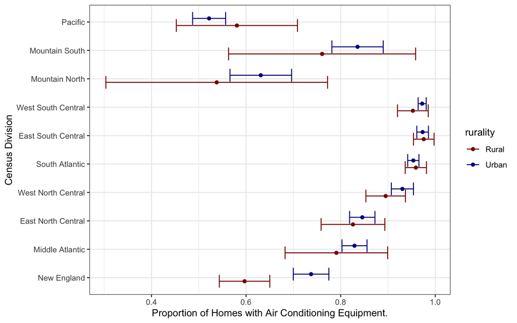

**Figure 1.** *Estimated Proportion of Homes with Air Conditioning Equipment by rurality in each Census Division in 2009.*

#### Proportion in 2015

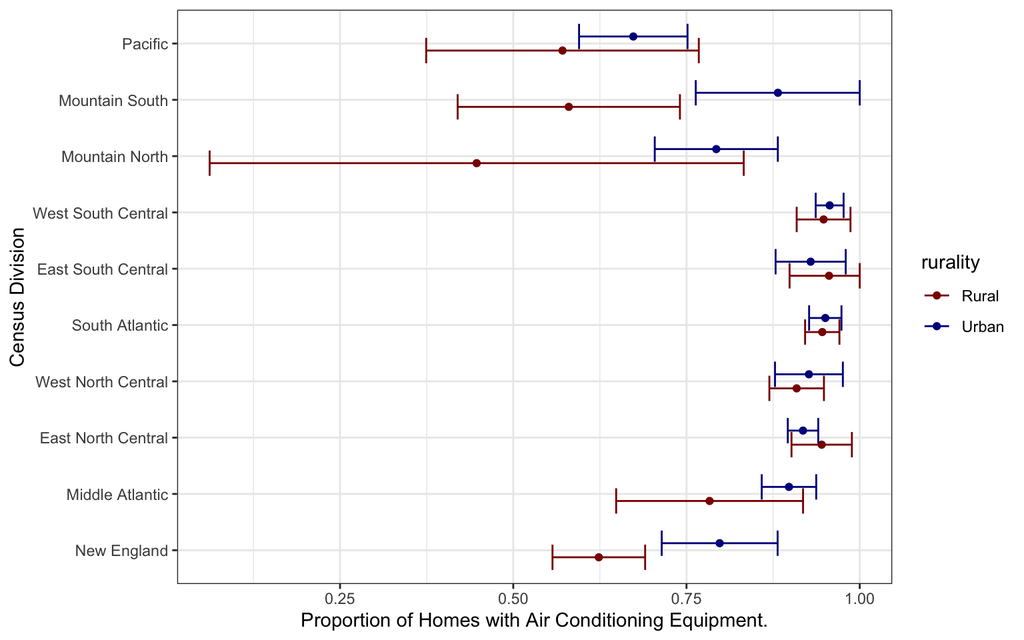

**Figure 2.** *Estimated Proportion of Homes with Air Conditioning Equipment by rurality in each Census Division in 2015.*

#### Proportion changes from 2009 to 2015

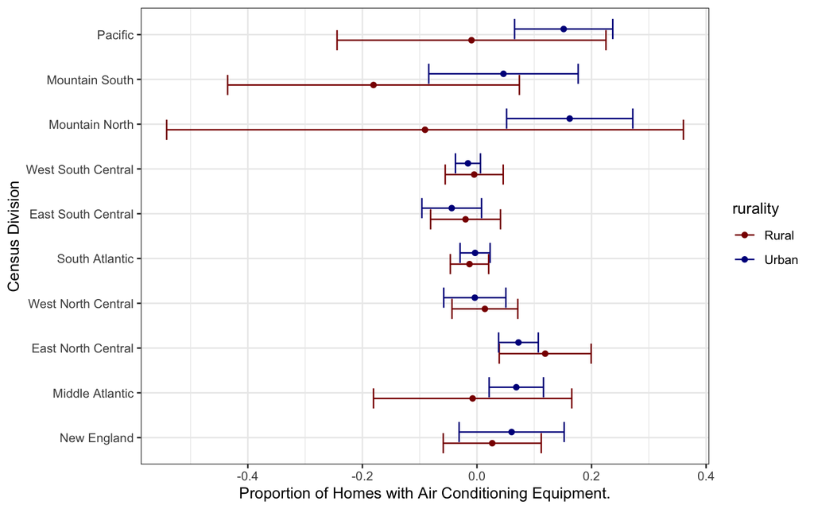

**Figure 3.** *Estimated Change of Proportion of Homes with Air Conditioning Equipment by rurality in each Census Division from 2009 to 2015.*

Through the above tables and figures, in 2009, South Atlantic, East South Central and West South Central have relatively high proportion of air conditioning equipment, and the proportion is quite similar among Rural and Urban Area. In 2015, except the above census division, East North Central and West North Central also have high proportion of air conditioning equipment. As for the difference from 2009 to 2015, the proportion of air conditioning equipment in rural area of East North Central, Urban area of Mountain North and Urban area of Pacific increase significantly. The proportion in rural region of Mountain South decreases sharply.

## Question 2

Click right to see the R code for answering this question.

```r
## Stats 506, Fall 2020 Problem Set 5 Question 1
##
## Author: Zhihao Xu, xuzhihao@umich.edu
## Updated: December 1, 2020
# 79: -------------------------------------------------------------------------
# libraries: ------------------------------------------------------------------
library(data.table)
library(parallel)

# directories: ----------------------------------------------------------------
path = './data/'

# data: -----------------------------------------------------------------------
ohxden = fread(paste0(path,'nhanes_ohxden.csv'))
demo = fread(paste0(path,'nhanes_demo.csv'))

ohxden[demo, on="SEQN"][OHDDESTS==1,]

ohx_long = melt(ohxden[demo, on="SEQN"][OHDDESTS==1,],
                id.vars = 'SEQN',
                measure.vars = paste0('OHX',sprintf("%02d", 1:32),"TC"),
                value.name = 'tooth_status',
                variable.name = 'tooth')

ohx_long = demo[ohx_long, on="SEQN"
              ][,.(id = SEQN, ohx_status = 1, tooth,
                   tooth_status, age = RIDAGEYR)
              ][order(id, tooth)]
ohx_long[, perm_tooth := (tooth_status==2)]

year = (ohx_long[,id]>= 62161) + (ohx_long[,id]>=73557) +
       (ohx_long[,id]>=83732) + (ohx_long[,id]>=93703)
year = factor(year, levels = 1:4,
              labels = c("2011-2012", "2013-2014", "2015-2016", "2017-2018"))
ohx_long[, year := year]




year_list = list("2011-2012", "2013-2014", "2015-2016", "2017-2018")
year_tooth = cbind(rep(paste0('OHX',sprintf("%02d", 1:32),"TC"),each=4),
                   rep(c("2011-2012", "2013-2014",
                         "2015-2016", "2017-2018"),32))
year_tooth = apply(year_tooth, 1, list)

bam_appro1 = function(y) {
  # used in mclapply function
  # implement the approach 1
  # fit the logistic regression model and predict using cross-validation
  # Inputs:
  #   y - year chosed as validate data
  # Output: prediction of probability for validation data
  train_data = ohx_long[year!=y,]
  test_data = ohx_long[year==y,]
  m = mgcv::bam(perm_tooth ~ tooth + s(age, bs = 'cs') + s(id, bs = 're'),
                  family=binomial(), data = train_data, discrete=TRUE)
  pred = predict(m, test_data, type="response")
  return(pred)
}
bam_appro2 = function(y) {
  # used in mclapply function
  # implement the approach 2
  # fit the logistic regression model and predict using cross-validation
  # Inputs:
  #   y - year chosed as validate data
  # Output: prediction of probability for validation data
  train_data = ohx_long[year!=y,]
  test_data = ohx_long[year==y,]
  m = mgcv::bam(perm_tooth ~ tooth + s(age, bs = 'cs', by = tooth)
                                   + s(id, bs = 're'),
                family=binomial(), data = train_data, discrete=TRUE)
  pred = predict(m, test_data, type="response")
  return(pred)
}

bam_appro3 = function(y) {
  # used in mclapply function
  # implement the approach 3
  # fit the logistic regression model and predict using cross-validation
  # Inputs:
  #   y - y[[1]] is a length 2 vector, first element is the target tooth and
  #       second element is the year chosed as validate data
  # Output: prediction of probability for validation data
  y = y[[1]]
  train_data = ohx_long[(year!=y[2])&(tooth==y[1]),]
  test_data = ohx_long[(year==y[2])&(tooth==y[1]),]
  m = mgcv::bam(perm_tooth ~ s(age, bs = 'cs'),
                family=binomial(), data = train_data, discrete=TRUE)
  pred = predict(m, test_data, type="response")
  return(pred)
}

order_true_y = function(y) {
  # used in mclapply function
  # reorder the true value of response to match the prediction
  # Inputs:
  #   y - y[[1]] is a length 2 vector, first element is the target tooth and
  #       second element is the year chosed as validate data
  # Output: true value after reording
  y = y[[1]]
  true = ohx_long[(year==y[2])&(tooth==y[1]),perm_tooth]+0
  return(true)
}

results1 = do.call("c", mclapply(year_list, bam_appro1, mc.cores = 4))
results2 = do.call("c", mclapply(year_list, bam_appro2, mc.cores = 4))
results3 = do.call("c", mclapply(year_tooth, bam_appro3, mc.cores = 4))
true_y3 = do.call("c", mclapply(year_tooth, order_true_y, mc.cores = 4))
true_y = ohx_long[,perm_tooth]+0


ce_loss1 = -mean(true_y * log(results1) + (1 - true_y) * log(1 - results1))
ce_loss2 = -mean(true_y * log(results2) + (1 - true_y) * log(1 - results2))
ce_loss3 = -mean(true_y3 * log(results3) + (1 - true_y3) * log(1 - results3))






#! Keep this as a reference for code length at
#! the top and bottom of your scripts.
# 79: -------------------------------------------------------------------------
```

Here is some part of `ohx_long` to preview, which is the same as the given screen-shot:

```
##              id ohx_status   tooth tooth_status age perm_tooth      year
##       1:  62161          1 OHX01TC            4  22      FALSE 2011-2012
##       2:  62161          1 OHX02TC            2  22       TRUE 2011-2012
##       3:  62161          1 OHX03TC            2  22       TRUE 2011-2012
##       4:  62161          1 OHX04TC            2  22       TRUE 2011-2012
##       5:  62161          1 OHX05TC            2  22       TRUE 2011-2012
##      ---
## 1099516: 102956          1 OHX28TC            2  38       TRUE 2017-2018
## 1099517: 102956          1 OHX29TC            2  38       TRUE 2017-2018
## 1099518: 102956          1 OHX30TC            2  38       TRUE 2017-2018
## 1099519: 102956          1 OHX31TC            4  38      FALSE 2017-2018
## 1099520: 102956          1 OHX32TC            4  38      FALSE 2017-2018
```

In the data analysis part, we divided the data into 4 cohorts by year, and implement the following approach and compute the corresponding cross entropy loss of these approach:

1. Use logistic regression to model the probability that a tooth is present as a smooth function of age (using a cubic smoothing spline) common to all teeth and a per-tooth indicator variable. Account for dependence among teeth within an individual subject using a random intercept. Using the variable names from the screen shot in part “a” the formula is:  
   `perm_tooth ~ tooth + s(age, bs = 'cs') + s(id, bs = 're')`.  
   The cross-entropy loss for this approach is 0.3603285.
2. Repeat the previous approach, but include an interaction between tooth and age as follows:  
   `perm_tooth ~ tooth + s(age, bs = 'cs', by = tooth) + s(id, bs = 're')`.  
   The cross-entropy loss for this approach is 0.3103066.
3. Repeat the previous step by modeling each tooth separately, so that the random intercepts are no longer needed:  
   `perm_tooth ~ s(age, bs = 'cs')`.  
   The cross-entropy loss for this approach is 0.3103584.

Overall, approach 2 and approach 3 have quite similar results, the best approach here is approach 2 with cross-entropy loss 0.3103066,